# xwMOOC 딥러닝

비행기 vs 자동차 - 강아지 vs 고양이

# 1. 이미지 분류 캐글 도전과제 [^1]

캐글에 4년전에 게시된 [Dogs vs. Cats - Create an algorithm to distinguish dogs from cats](https://www.kaggle.com/c/dogs-vs-cats)문제는 이미지에 포함된 동물이 강아지인지 고양이인지 분류하는 문제다. 특히 텐서플로우를 가지고 이미지분류를 시작할 때 처음 다루는 데이터이기도 하다.

# 2. 이미지 데이터 가져오기

이미지 분류를 시작할 때 가장 먼저 이미지 데이터를 구해야 된다. 이를 위해서 이미지 검색엔진을 사용해서 검색어를 넣고 이를 바탕으로 이미지를 한땀 한땀 불러내서 저장하는 것이다. [R 팬텀JS (phantomJS) - 방송3사 시청률 경쟁 그리고 JTBC 손석희 앵커](http://statkclee.github.io/data-science/ds-phantomJS.html)를 참조하여 원하는 데이터를 크롤링하는데 이미지라서 [How to Scrape Images from Google](https://flovv.github.io/scrape_images_google/)를 참조한다.

- phantomJS를 설치한다.
- `imageScrape.js` 파일으로 R로 가져와서 구글 이미지 검색어를 바꾸어서 `phantomJS`를 실행시킨다.
- 다운로드 받은 `1.html` 파일을 파싱하여 이미지 url을 추출한다.
- `downloadImages()` 함수를 참조하여 이미지를 다운로드한다.

```r
# 0. 환경설정 -----
library(tidyverse)
library(rvest)
library(keras) # install_keras()
library(EBImage)
library(reticulate)

# 1. 검색어 불러오기 -----

scrapeJSSite <- function(searchTerm){
    url <- paste0("https://www.google.de/search?q=",searchTerm, "&source=lnms&tbm=isch&sa=X")

    lines <- readLines("code/airplane_car/imageScrape.js")
    lines[1] <- paste0("var url ='", url ,"';")
    writeLines(lines, "code/airplane_car/imageScrape.js")

    ## 다운로드 웹사이트 실행
    system("phantomjs code/airplane_car/imageScrape.js")

    pg <- read_html("1.html")
    files <- pg %>% html_nodes("img") %>% html_attr("src")
    df <- data.frame(images=files, search=searchTerm)
    return(df)
}

# 2. 검색 이미지 다운로드 함수 -----

downloadImages <- function(files, type, outPath="data/images"){
    for(i in 1:length(files)){
        download.file(files[i], destfile = paste0(outPath, "/", type, "_", i, ".jpg"), mode = 'wb')
    }
}

# 3. 이미지 다운로드 실행 -----
## 3.1. 비행기 이미지 다운로드
airplane_df <- scrapeJSSite(searchTerm = "airplane") %>%
    filter(!str_detect(images, "tia.png"))

downloadImages(as.character(airplane_df$images), "airplane")

## 3.2. 자동차 이미지 다운로드
car_df <- scrapeJSSite(searchTerm = "car") %>%
    filter(!str_detect(images, "tia.png"))

downloadImages(as.character(car_df$images), "car")

## 3.3. 다운로드 받을 이미지 목록
image_df <- bind_rows(airplane_df, car_df)
DT::datatable(image_df)
```

|  | images | search |
| --- | --- | --- |
| 1 | https://encrypted-tbn0.gstatic.com/images?q=tbn:ANd9GcTaI-34Ud_bmt1BsF3drylodOBDKqT0DORfk36kzmLiIX06f5AymrgTC7A | airplane |
| 2 | https://encrypted-tbn0.gstatic.com/images?q=tbn:ANd9GcSa8reE1pT86Y_Ashc2dm9EkK70VfzFh-7OoJjAe_TEPn5DSGORBJYk6V2E | airplane |
| 3 | https://encrypted-tbn0.gstatic.com/images?q=tbn:ANd9GcSWSigxLPPjBJ3_4Dn_b79C9Tz8t3QjFrxlhRKQeIkc_ZB_sote7kAaPIY | airplane |
| 4 | https://encrypted-tbn0.gstatic.com/images?q=tbn:ANd9GcRmPHdV0WCDiAalr8ed5DSHIedDr9LYAakSzbhOLLGGkaU_8rpKX7qIoA | airplane |
| 5 | https://encrypted-tbn0.gstatic.com/images?q=tbn:ANd9GcRxCEiWpSg9NT6pzv8ki0Fpe3mibIcwjLzvlG0NEKlQLphCss0A5unSwCo | airplane |
| 6 | https://encrypted-tbn0.gstatic.com/images?q=tbn:ANd9GcSY7g7zhgNFR9gTmdvGc5li7WJW7Ai3Usqran_gAatE9r_GyzHsymCRvw | airplane |
| 7 | https://encrypted-tbn0.gstatic.com/images?q=tbn:ANd9GcRZCoW7nmcVzqCioNXuC6lzKX3_BzqpyMyYNa8uvSAXLibPfEBaAN7fEiw | airplane |
| 8 | https://encrypted-tbn0.gstatic.com/images?q=tbn:ANd9GcR31AJPXAyA0tRlHpR82nlcF8INvTtKczvZqyvkq12zxxI9OWM-RFq-7VGx | airplane |
| 9 | https://encrypted-tbn0.gstatic.com/images?q=tbn:ANd9GcRlqz9GPcEJf9JsqlcVG_91EjK1Mmbdw4F2_0Mw_Wk4k2lLkkH_LS5_H5-Z | airplane |
| 10 | https://encrypted-tbn0.gstatic.com/images?q=tbn:ANd9GcR6FCgq8YS1VWcwllUpcTcGVoKxf6vw3VRZWtJXI3fmeusFyudWs2KGlobZ | airplane |

[output cut: 30 more lines]

# 3. 이미지 데이터 살펴보기

[figure not shown]

```r
# 1. 이미지 불러오기 -----

img_lst <- list.files("data/images/")
img_lst <- map(img_lst, function(x) paste0("data/images/", x))

imgs_lst <- map(img_lst, readImage)

## 1.1. 이미지 살펴보기 -----

par(mfrow = c(8,5))
for (i in 1:40) plot(imgs_lst[[i]])
```

이미지 크기가 균일하지 않기 때문에 `EBImage` 팩키지 `resize()` 함수를 통해 폭(width, w)과 높이(height, h)가 28인 크기로 통일시킨 후에 `combine()` 함수와 `tile()` 함수를 통해 하나의 그래프로 만들어 살펴본다.

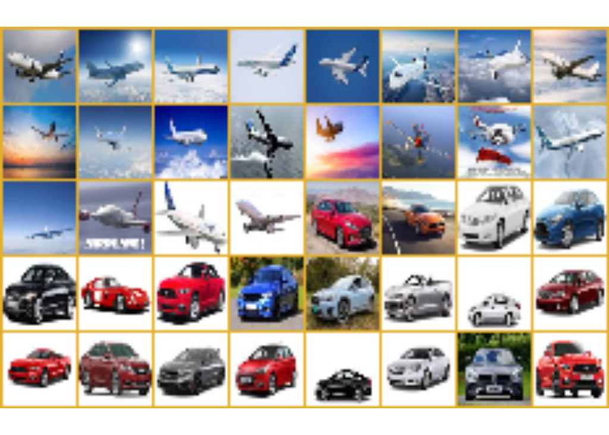

```r
# 2. 이미지 시각화 -----
imgs_resize_lst <- map(imgs_lst, resize, w =28, h=28)

imgs_resize_combined <- combine(imgs_resize_lst)

tile(imgs_resize_combined, 8) %>%
    display()
```

[^1]: [Dogs vs. Cats: Image Classification with Deep Learning using TensorFlow in Python](https://www.datasciencecentral.com/profiles/blogs/dogs-vs-cats-image-classification-with-deep-learning-using)